# Assessment

2025-11-18

Research Question: How do prescribing rates of specific sexually transmitted infection (STI) treatments vary across socioeconomic deprivation levels (SIMD deciles) in Scotland during 2024?

```r
library(tidyverse)
library(janitor) # cleaning data
library(gt) # tables
library(here) # directory structure
#Importing all the prescription data and removing unnecessary columns

data_january2024 <- read_csv("https://www.opendata.nhs.scot/dataset/84393984-14e9-4b0d-a797-b288db64d088/resource/d3eaaf84-0f3b-4fb8-9460-e33503095fbe/download/pitc202401.csv") %>%
  clean_names()
data_february2024 <- read_csv("https://www.opendata.nhs.scot/dataset/84393984-14e9-4b0d-a797-b288db64d088/resource/86fda652-0e1d-48bb-9368-aa2a560d925b/download/pitc202402.csv") %>%
  clean_names()
data_march2024 <- read_csv("https://www.opendata.nhs.scot/dataset/84393984-14e9-4b0d-a797-b288db64d088/resource/a42762ac-47cb-4fb6-b9b1-2478a588c0ed/download/pitc202403.csv") %>%
  clean_names()
data_april2024 <- read_csv("https://www.opendata.nhs.scot/dataset/84393984-14e9-4b0d-a797-b288db64d088/resource/409a02f2-b77c-47a0-917d-4a5a1c90f182/download/pitc202404.csv") %>%
  clean_names()
data_may2024 <- read_csv("https://www.opendata.nhs.scot/dataset/84393984-14e9-4b0d-a797-b288db64d088/resource/5fbbd126-6166-4249-9620-7ed78e877297/download/pitc202405.csv") %>%
  clean_names()
data_june2024 <- read_csv("https://www.opendata.nhs.scot/dataset/84393984-14e9-4b0d-a797-b288db64d088/resource/95f7f250-bd04-4e4a-b853-5df75b00a632/download/pitc202406.csv") %>%
  clean_names()
data_july2024 <- read_csv("https://www.opendata.nhs.scot/dataset/84393984-14e9-4b0d-a797-b288db64d088/resource/1cb425fc-640c-4b37-9013-f8e97f274085/download/pitc202407.csv") %>%
  clean_names()
data_august2024 <- read_csv("https://www.opendata.nhs.scot/dataset/84393984-14e9-4b0d-a797-b288db64d088/resource/e4985a62-9d59-4e71-8800-3f7ca29ffe0c/download/pitc202408.csv") %>%
  clean_names()
data_september2024 <- read_csv("https://www.opendata.nhs.scot/dataset/84393984-14e9-4b0d-a797-b288db64d088/resource/d1fbede3-98c4-436e-9e75-2ed807a36075/download/pitc202409.csv") %>%
  clean_names()
data_october2024 <- read_csv("https://www.opendata.nhs.scot/dataset/84393984-14e9-4b0d-a797-b288db64d088/resource/0d27f6e8-5f8b-42c4-9fe9-c44389af2d3e/download/pitc202410.csv") %>%
  clean_names()
data_november2024 <- read_csv("https://www.opendata.nhs.scot/dataset/84393984-14e9-4b0d-a797-b288db64d088/resource/1b97dffc-310e-4a30-bf9c-22fddff3f499/download/pitc202411.csv") %>%
  clean_names()
data_december2024 <- read_csv("https://www.opendata.nhs.scot/dataset/84393984-14e9-4b0d-a797-b288db64d088/resource/e4380152-3d16-446b-9072-108e93cf5caa/download/pitc202412.csv") %>%
  clean_names()
data_january2024   <- data_january2024   %>% select(-c(dmd_code, bnf_item_code, prescribed_type))
data_february2024  <- data_february2024  %>% select(-c(dmd_code, bnf_item_code, prescribed_type))
data_march2024     <- data_march2024     %>% select(-c(dmd_code, bnf_item_code, prescribed_type))
data_april2024     <- data_april2024     %>% select(-c(dmd_code, bnf_item_code, prescribed_type))
data_may2024       <- data_may2024       %>% select(-c(dmd_code, bnf_item_code, prescribed_type))
data_june2024      <- data_june2024      %>% select(-c(dmd_code, bnf_item_code, prescribed_type))
data_july2024      <- data_july2024      %>% select(-c(dmd_code, bnf_item_code, prescribed_type))
data_august2024    <- data_august2024    %>% select(-c(dmd_code, bnf_item_code, prescribed_type))
data_september2024 <- data_september2024 %>% select(-c(dmd_code, bnf_item_code, prescribed_type))
data_october2024   <- data_october2024   %>% select(-c(dmd_code, bnf_item_code, prescribed_type))
data_november2024  <- data_november2024  %>% select(-c(dmd_code, bnf_item_code, prescribed_type))
data_december2024  <- data_december2024  %>% select(-c(dmd_code, bnf_item_code, prescribed_type))
```

```r
#Joining all of the months for 2024
prescriptions_2024 <- bind_rows(data_january2024, data_february2024, data_march2024,data_april2024,data_may2024, data_june2024, data_july2024, data_august2024, data_september2024, data_october2024, data_november2024, data_december2024)

#Checking if they have binded correctly
prescriptions_2024 %>% count(paid_date_month)
```

```
## # A tibble: 12 × 2
##    paid_date_month       n
##              <dbl>   <int>
##  1          202401 1268374
##  2          202402 1270380
##  3          202403 1261071
##  4          202404 1267246
##  5          202405 1296124
##  6          202406 1265703
##  7          202407 1284000
##  8          202408 1281939
##  9          202409 1240695
## 10          202410 1289183
## 11          202411 1254728
## 12          202412 1278137
```

```r
#Removing data to save memory
rm(data_january2024, data_february2024, data_march2024,data_april2024,data_may2024, data_june2024, data_july2024, data_august2024, data_september2024, data_october2024, data_november2024, data_december2024)
```

```r
#Importing GP data for location
GP_2024 <- read_csv("https://www.opendata.nhs.scot/dataset/f23655c3-6e23-4103-a511-a80d998adb90/resource/215e9157-ccf2-47ab-aba5-4fb79eb32e41/download/practice_contactdetails_jul2024-open-data.csv") %>%
  clean_names()
names(GP_2024)
```

```
##  [1] "practice_code"      "gp_practice_name"   "practice_list_size"
##  [4] "address_line1"      "address_line2"      "address_line3"
##  [7] "address_line4"      "postcode"           "telephone_number"
## [10] "practice_type"      "dispensing"         "hb"
## [13] "hscp"               "data_zone"          "gp_cluster"
```

```r
#Selecting relevant columns and ensuring there is no row duplication in unique gp identifier (practice code)
GP_2024 <- GP_2024 %>%
  select(practice_code, practice_list_size, data_zone, gp_cluster) %>%
  distinct(practice_code, .keep_all = TRUE)
```

```r
#Importing SIMD data for deprivation score
SIMD <- read_csv("https://www.opendata.nhs.scot/dataset/78d41fa9-1a62-4f7b-9edb-3e8522a93378/resource/acade396-8430-4b34-895a-b3e757fa346e/download/simd2020v2_22062020.csv") %>%
  clean_names()
names(SIMD)
```

```
##  [1] "data_zone"                  "int_zone"
##  [3] "hb"                         "hscp"
##  [5] "ca"                         "simd2020v2rank"
##  [7] "simd2020v2country_decile"   "simd2020v2country_quintile"
##  [9] "simd2020v2hb_decile"        "simd2020v2hb_quintile"
## [11] "simd2020v2hscp_decile"      "simd2020v2hscp_quintile"
## [13] "simd2020v2ca_decile"        "simd2020v2ca_quintile"
## [15] "simd2020v2most15pc"         "simd2020v2least15pc"
```

```r
#Selecting relevant columns and ensuring there is no row duplication in unique region identifier (data zone)
SIMD <- SIMD %>%
  select(data_zone, simd_rank   = simd2020v2rank, simd_decile = simd2020v2country_decile) %>%
  distinct(data_zone, .keep_all = TRUE)
```

```r
# Ensure GP identifiers match in type before joining (required because one was numeric and the other character)
prescriptions_2024 <- prescriptions_2024 %>%
  mutate(gp_practice = as.character(gp_practice))

GP_2024 <- GP_2024 %>%
  mutate(practice_code = as.character(practice_code))

# Join prescriptions with GP data (adds list size + data zone to each prescription)
presc_gp <- prescriptions_2024 %>%
  left_join(GP_2024, by = c("gp_practice" = "practice_code"))

# Join with SIMD data using data_zone (both already character, so no conversion needed)
final_dataset <- presc_gp %>%
  left_join(SIMD, by = "data_zone")
```

```r
#Removing data to save memory
rm(GP_2024, presc_gp, prescriptions_2024, SIMD)
```

```r
#Identifying GP practices that did not successfully match to GP location data
gp_missing <- final_dataset %>%
  distinct(gp_practice, data_zone) %>%
  filter(is.na(data_zone))

gp_missing
```

```
## # A tibble: 262 × 2
##    gp_practice data_zone
##    <chr>       <chr>
##  1 80260       <NA>
##  2 80804       <NA>
##  3 80819       <NA>
##  4 80823       <NA>
##  5 80838       <NA>
##  6 80951       <NA>
##  7 81027       <NA>
##  8 81046       <NA>
##  9 81101       <NA>
## 10 99996       <NA>
## # ℹ 252 more rows
```

```r
#Keeping only rows with valid GP location and SIMD deprivation information
analysis_data <- final_dataset %>%
  drop_na(data_zone, simd_decile)
```

```r
#Checking which specific columns still contain missing values
colSums(is.na(analysis_data))
```

```
##                   hbt           gp_practice  bnf_item_description
##                     0                     0                 54793
##  number_of_paid_items         paid_quantity gross_ingredient_cost
##                     0                     0                     0
##       paid_date_month    practice_list_size             data_zone
##                     0                     0                     0
##            gp_cluster             simd_rank           simd_decile
##                     0                     0                     0
```

```r
library(stringr)

#List of STI-related drugs to search for according to Tuddenham, S., Hamill, M.M. and Ghanem, K.G (2022)
sti_drugs <- c("CEFTRIAXONE", "CEFIXIME", "GENTAMICIN", "AZITHROMYCIN", "DOXYCYCLINE", "LEVOFLOXACIN", "AMOXICILLIN", "ERYTHROMYCIN", "BENZATHINE BENZYLPENICILLIN", "PROCAINE BENZYLPENICILLIN", "MOXIFLOXACIN", "METRONIDAZOLE", "TINIDAZOLE")

#Create a single search pattern to identify any STI drug in the dataset
sti_pattern <- paste(sti_drugs, collapse = "|")

#Keep only prescriptions that relate to STI treatments
sti_data <- analysis_data %>%
  filter(!is.na(bnf_item_description), str_detect(bnf_item_description, sti_pattern))
```

```r
#Removing data to save memory
rm(analysis_data, final_dataset, gp_missing)
```

```r
#Add a clean drug name label for each prescription
sti_data <- sti_data %>%
  mutate(drug_name = case_when(str_detect(bnf_item_description, "CEFTRIAXONE") ~ "Ceftriaxone", str_detect(bnf_item_description, "CEFIXIME") ~ "Cefixime", str_detect(bnf_item_description, "GENTAMICIN") ~ "Gentamicin", str_detect(bnf_item_description, "AZITHROMYCIN") ~ "Azithromycin", str_detect(bnf_item_description, "DOXYCYCLINE") ~ "Doxycycline", str_detect(bnf_item_description, "LEVOFLOXACIN") ~ "Levofloxacin", str_detect(bnf_item_description, "AMOXICILLIN") ~ "Amoxicillin", str_detect(bnf_item_description, "ERYTHROMYCIN") ~ "Erythromycin", str_detect(bnf_item_description, "BENZATHINE BENZYLPENICILLIN") ~ "Benzathine benzylpenicillin", str_detect(bnf_item_description, "PROCAINE BENZYLPENICILLIN") ~ "Procaine benzylpenicillin", str_detect(bnf_item_description, "BENZYLPENICILLIN") ~ "Benzylpenicillin", str_detect(bnf_item_description, "MOXIFLOXACIN") ~ "Moxifloxacin", str_detect(bnf_item_description, "METRONIDAZOLE") ~ "Metronidazole", str_detect(bnf_item_description, "TINIDAZOLE") ~ "Tinidazole", str_detect(bnf_item_description, "ACICLOVIR") ~ "Aciclovir", str_detect(bnf_item_description, "VALACICLOVIR") ~ "Valaciclovir", str_detect(bnf_item_description, "FAMCICLOVIR") ~ "Famciclovir", TRUE ~ NA_character_))
```

```r
#Checking which specific columns still contain missing values
colSums(is.na(sti_data))
```

```
##                   hbt           gp_practice  bnf_item_description
##                     0                     0                     0
##  number_of_paid_items         paid_quantity gross_ingredient_cost
##                     0                     0                     0
##       paid_date_month    practice_list_size             data_zone
##                     0                     0                     0
##            gp_cluster             simd_rank           simd_decile
##                     0                     0                     0
##             drug_name
##                     0
```

```r
#Calculating overall STI prescribing (across all drugs) for each SIMD decile
sti_overall <- sti_data %>%
  group_by(data_zone, simd_decile) %>%
  summarise(sti_items = sum(number_of_paid_items, na.rm = TRUE), list_size = mean(practice_list_size, na.rm = TRUE)) %>%
  mutate(sti_items_per_1000 = 1000 * sti_items / list_size) %>%
  group_by(simd_decile) %>%
  summarise(mean_rate = mean(sti_items_per_1000, na.rm = TRUE))
```

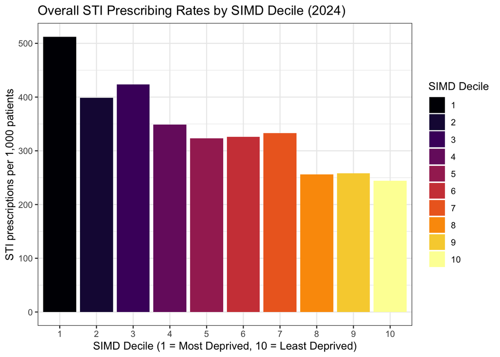

```r
#Simple bar chart
sti_simple_plot <- sti_overall %>%
  ggplot(aes(x = factor(simd_decile), y = mean_rate, fill = factor(simd_decile))) +
  geom_col() +
  scale_fill_viridis_d(option = "inferno") +
  labs(title = "Overall STI Prescribing Rates by SIMD Decile (2024)", x = "SIMD Decile (1 = Most Deprived, 10 = Least Deprived)", y = "STI prescriptions per 1,000 patients", fill = "SIMD Decile") +
  theme_bw()

sti_simple_plot
```

To understand why this pattern appears, the next step is to break the data down by individual drugs. Different STI treatments vary in cost, usage, and clinical purpose, so looking at them separately will show whether all drugs follow the same deprivation trend or whether certain treatments drive the pattern more than others.

By examining each drug’s prescribing rate across SIMD deciles, it becomes possible to see whether access, clinical demand, or socioeconomic factors differ between treatments. This will help explain the overall gradient and reveal which drugs contribute most to the disparity.

```r
#Calculate STI prescribing at the data-zone level
sti_by_zone <- sti_data %>%
  group_by(data_zone, simd_decile, drug_name) %>%
  summarise(sti_items = sum(number_of_paid_items), list_size = mean(practice_list_size)) %>%
  mutate(sti_items_per_1000 = (sti_items / list_size) * 1000)
```

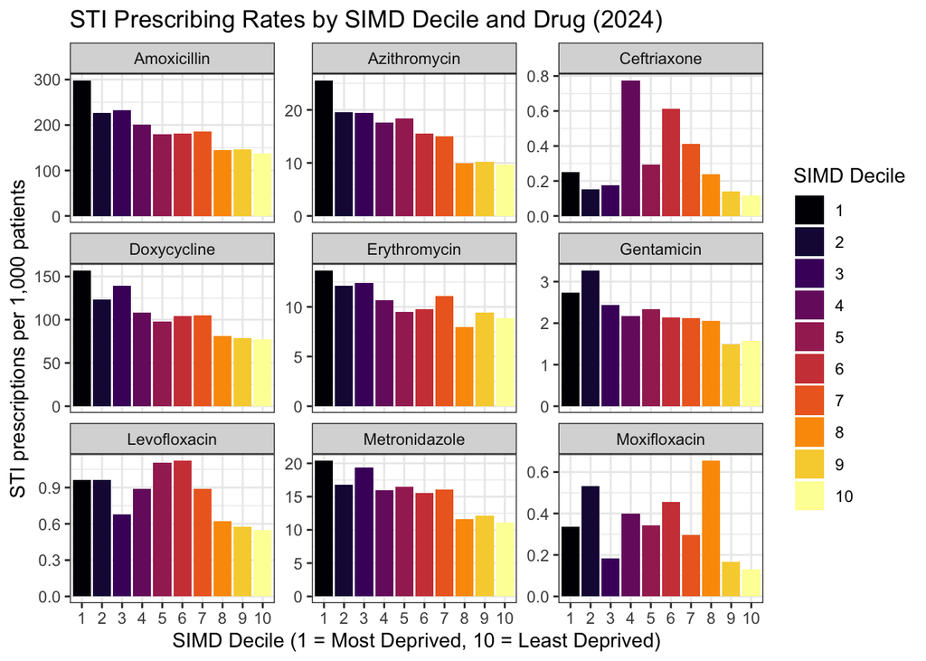

```r
#Create a dataset summarising STI prescribing for each drug within each SIMD decile
sti_plot <- sti_by_zone %>%
  group_by(simd_decile, drug_name) %>%
  summarise(mean_sti_rate = mean(sti_items_per_1000)) %>%
  ggplot(aes(x = factor(simd_decile), y = mean_sti_rate, fill = factor(simd_decile))) +
  geom_col() +
  facet_wrap(~ drug_name, scales = "free_y") +
  scale_fill_viridis_d(option = "inferno") +
  labs(title = "STI Prescribing Rates by SIMD Decile and Drug (2024)", x = "SIMD Decile (1 = Most Deprived, 10 = Least Deprived)", y = "STI prescriptions per 1,000 patients", fill = "SIMD Decile") +
  theme_bw()
sti_plot
```

A potential next step is to examine whether the cost of different STI treatments contributes to the prescribing differences across SIMD deciles, helping to determine if price plays a role in the observed deprivation gradient